# OBESIDADE E INATIVIDADE FÍSICA COMO FATORES DE RISCO DE MORTALIDADE NA POPULAÇÃO BRASILEIRA

OBESIDADE E INATIVIDADE FÍSICA COMO FATORES DE RISCO DE MORTALIDADE NA POPULAÇÃO BRASILEIRA Saulo Gil, Phd 26/05/2021

O objetivo deste projeto foi verificar os países com maior taxa de mortalidade a partir da análise da base de dados disponibilizada pela Organização Mundial de Saúde (World Health Organization – WHO), verificar como o Brasil está disposto nesta lista considerando todos os países do mundo e os países da América do Sul no qual o Brasil faz parte e, por fim, verificar a prevalência de obesidade e inatividade, ambos fatores de risco para mortalidade. Após a analise da base de dados de mortalidade da WHO nota-se que o Brasil encontra-se na posição 86 quando considerado todos os países do munto. A tabela abaixo (Tabela 1) apresenta os dados por pais dividido por sexo a fim de ilustrar a taxa de mortalidade de adutos listados em ordem alfabética.

Tabela 1. Taxa de mortalidade de adultos (probabilidade de morrer entre 15 e 60 anos por 1000 habitantes).

| País | Ambos sexos | Homem | Mulher |
| --- | --- | --- | --- |
| Afghanistan | 245 | 272 | 216 |
| Albania | 96 | 122 | 71 |
| Algeria | 95 | 106 | 84 |
| Angola | 238 | 275 | 202 |
| Antigua and Barbuda | 120 | 137 | 104 |
| Argentina | 111 | 143 | 80 |
| Armenia | 116 | 176 | 65 |
| Australia | 61 | 77 | 45 |
| Austria | 62 | 80 | 44 |
| Azerbaijan | 118 | 160 | 76 |
| Bahamas | 159 | 199 | 120 |
| Bahrain | 57 | 61 | 50 |
| Bangladesh | 130 | 150 | 110 |
| Barbados | 100 | 129 | 74 |
| Belarus | 161 | 241 | 82 |
| Belgium | 72 | 89 | 54 |
| Belize | 179 | 225 | 132 |
| Benin | 242 | 265 | 220 |
| Bhutan | 207 | 205 | 209 |
| Bolivia (Plurinational State of) | 182 | 214 | 150 |
| Bosnia and Herzegovina | 92 | 120 | 63 |
| Botswana | 249 | 294 | 208 |
| Brazil | 143 | 194 | 91 |
| Brunei Darussalam | 98 | 111 | 83 |
| Bulgaria | 135 | 183 | 85 |
| Burkina Faso | 255 | 273 | 239 |
| Burundi | 290 | 320 | 260 |
| Cabo Verde | 122 | 146 | 100 |
| Cambodia | 170 | 205 | 140 |
| Cameroon | 341 | 362 | 321 |

[output cut: 153 more lines]

[figure not shown]

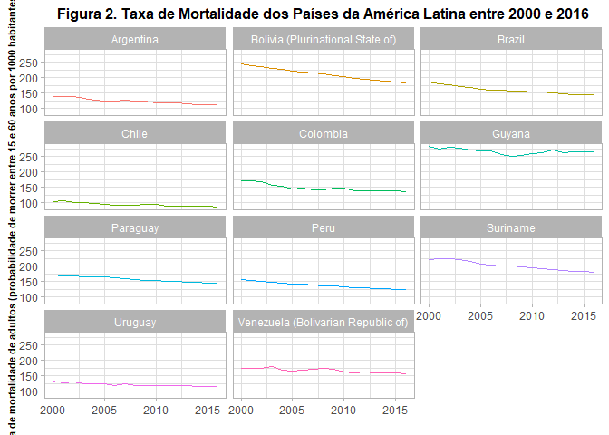

A obesidade e a inatividade física são reconhecidos preditores independentes de mortalidade em distintas populações. Neste sentido, é razoável especular que o Brasil apresente uma elevada prevalência de obesidade e inatividade física o que poderia explicar, ao menos parcialmente, a elevada e sustentada probabilidade de mortalidade observada na última década. Além disso, tanto a obesidade quanto a inatividade física estão associados a diversas doenças cardiometabólicas tais como diabetes e hipertensão arterial e, como consequência, a uma piora na qualidade de vida. A série temporal de dados disponibilizados pela WHO sobre obesidade mostra que desde o ano de 2000 o Brasil apresenta um aumento na prevalência de obesidade. No ano de 2016, 22% da população apresentava um índice de massa corporal (IMC) > que 30 kg/m². A Figura 3 ilustra a prevalência da obesidade na população brasileira entre os anos 2000 e 2016.

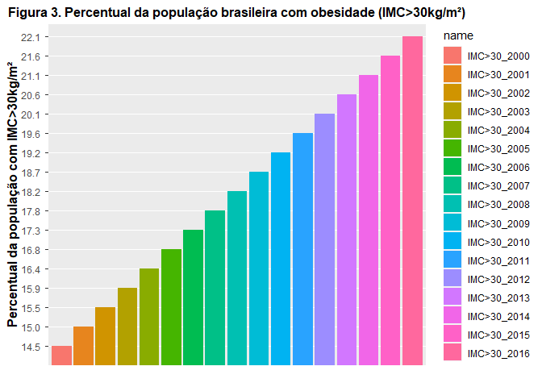

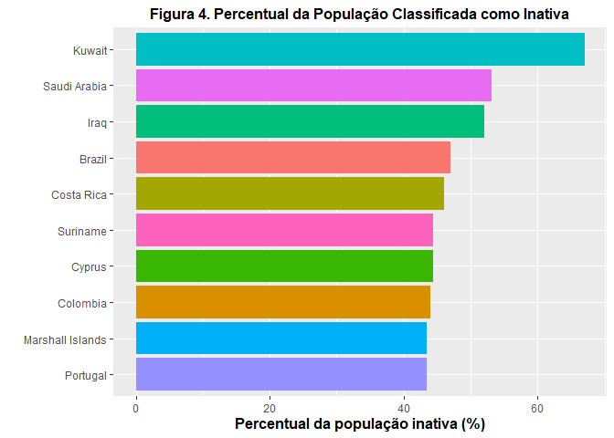

Por fim, com base na análise das bases de dados da WHO de probabilidade de mortalidade, prevalência de obesidade e nível de atividade física é possível verificar que o Brasil apresenta uma elevada prevalência de obesidade (22%) e inatividade física (47%) em sua população. Esses resultados sugerem que políticas públicas devem buscar estratégias para reduzir os índices de obesidade e inatividade física uma vez que estas condições são reconhecidos preditores de doenças cardiometabólicas e mortalidade. Cumpre destacar que as analises aqui apresentadas não indicam uma relação de causalidade entre as variáveis e alguma cautela deve ser tomada na interpretação desses resultados.